# 4. Cell composition: Whole Blood

Whole blood is comprised of multiple cell types. It is a mixture of neutrophils, monocytes, natural killer (NK) cells, B cells, and CD4+/CD8+ T cells, and each cell type has a distinctly different methylome. When you draw blood from two people, differences in their cell-type *proportions* — driven by age, infection, stress, time of day — can produce large methylation differences that are unrelated to the biology you’re studying. For most blood EWAS, cell composition is a large source of confounding (Houseman et al. 2012; Jaffe and Irizarry 2014). This notebook estimates the proportions, explains the reference-based method, and validates our estimates against the proportions the study deposited.

**NoteWhat this chapter needs**

This chapter starts from `data/01_RGset.rds`, written by chapter 0. If you did not run that chapter, fetch the published checkpoint instead:

```
Terminal
```

```bash
./get_data.sh B_qc
```

```r
library(minfi)                  # estimateCellCounts2(), getBeta()
library(FlowSorted.Blood.EPIC)  # the flow-sorted EPIC reference and the IDOL probe library
library(GEOquery)               # getGEO(), for the study's own deposited proportions
library(data.table)             # fread() for the deposited table
library(ggplot2)                # every figure in this chapter
library(dplyr)                  # joins for the deposited table, bind_rows() for the figure
library(tibble)                 # rownames_to_column() before the join

# The raw two-channel object written by the Setup chapter: 1,051,943 CpGs
# across 96 arrays, with no normalization applied. Deconvolution is one of the
# few steps that needs the raw intensities rather than the normalized object
# from chapter 2 -- the reason is in the callout below.
rg <- readRDS("data/01_RGset.rds")
```

## 4.1 Why cell composition matters

A neutrophil and a CD4+ T cell carry the same genome but very different DNA methylation. A whole-blood methylation measurement at any CpG is therefore a **weighted average** across the cell types present, with weights equal to the cell proportions:

$$\beta_{\text{observed}} \approx \sum_{k} w_k \, \beta_k$$

where $w_k$ is the fraction of cell type $k$ and $\beta_k$ is that cell type’s methylation at the CpG. If cases have more neutrophils than controls — even for reasons unrelated to the exposure — every cell-type-discriminating CpG will look “differentially methylated.” Neutrophil fraction alone routinely explains the largest chunk of genome-wide methylation variance in blood.

## 4.2 Reference-based deconvolution (Houseman)

The standard approach is the **Houseman method** (Houseman et al. 2012):

1. Start from a **reference** of purified, flow-sorted blood cell types, each profiled on the same array platform. For each cell type we know its methylation at a panel of cell-type-discriminating CpGs.
2. Choose the discriminating CpGs. The original method picked them by F-test; the **IDOL** optimization (Salas et al. 2018) selects a library that minimizes deconvolution error and is the current best practice for EPIC. We use the IDOL-optimized 450-CpG library from `FlowSorted.Blood.EPIC`.
3. For each sample, solve a **constrained regression** (proportions ≥ 0, summing to ~1) of the observed methylation at those CpGs against the reference profiles. The fitted coefficients are the estimated cell proportions.

Crucially, the sample and reference data must be **normalized together** so that technical differences don’t confound composition. `minfi`’s `estimateCellCounts2` handles this by combining `RGChannelSet` with the reference `RGChannelSet`, normalizing jointly (here with noob), then deconvolving:

```r
# The IDOL-optimized probe library ships with FlowSorted.Blood.EPIC as a dataset
# rather than a function, so it has to be attached before it can be passed in.
data("IDOLOptimizedCpGs")

# Set the psuedo-random seed
set.seed(1)

# This is the most memory-intensive step in the whole tutorial: 15.0 GB peak.
# The collapsed callout further down gives instructions on how to download the
# precomputed estimated cell counts if you don't have the resources to do this
# step on your own computer.
cc <- estimateCellCounts2(
  rg,                                   # raw RGChannelSet (not yet normalized)
  compositeCellType   = "Blood",
  processMethod       = "preprocessNoob",
  probeSelect         = "IDOL",
  cellTypes           = c("CD8T","CD4T","NK","Bcell","Mono","Neu"),
  referencePlatform   = "IlluminaHumanMethylationEPIC",
  IDOLOptimizedCpGs   = IDOLOptimizedCpGs,
  returnAll           = FALSE)
```

```r
# `prop` is the estimated proportion per cell type; the sibling `counts` element
# is only filled in when you supply absolute cell counts to compare against, so
# on this call it comes back empty. Read `prop`.
props <- cc$prop                        # 96 samples x 6 cell types
dim(props)
```

```
[1] 96  6
```

**NoteReference-based needs the *raw* data**

`estimateCellCounts2` starts from the raw `RGChannelSet`, not the normalized object from normalization, because it must normalize the samples *and* reference. This is one of the few steps that reaches back to the raw IDATs. The reference dataset itself is downloaded once from Bioconductor’s ExperimentHub and cached.

The first time you run this on a machine the cache does not exist yet, and R asks:

```
/home/you/.cache/R/ExperimentHub does not exist, create directory? (yes/no):
```

Answer `yes` — it is the standard per-user cache location, and you are asked once per machine. The question only appears in an interactive session (like an RStudio or PyCharm console). To put the cache somewhere else, set it before the call:

```
RStudio Console
```

```r
ExperimentHub::setExperimentHubOption("CACHE", "/path/of/your/choosing")
```

**NoteRunning out of memory on the chunk above**

The proportions this chapter writes at the end are committed to the repository, so you can skip the `deconvolve` chunk and read them instead if you don’t have the available RAM to run the deconvolution yourself:

```
RStudio Console
```

```r
props <- readRDS(url(paste0("https://raw.githubusercontent.com/krferrier/",
                            "Methylation-EWAS-tutorial/main/tutorial/data/",
                            "04_cellcounts.rds")))
```

## 4.3 The composition of this subset

```r
# Collapse the 96 x 6 matrix to one row per cell type: the mean proportion and
# the observed range across samples. Then, convert to percentages because they read
# more easily in a table.
comp <- data.frame(cell_type = colnames(props),
                   mean_pct   = round(100 * colMeans(props), 1),
                   min_pct    = round(100 * apply(props, 2, min), 1),
                   max_pct    = round(100 * apply(props, 2, max), 1))
comp <- arrange(comp, desc(mean_pct))
knitr::kable(comp, row.names = FALSE,
             caption = "Estimated cell-type composition across the 96 samples. Neutrophils dominate, as expected for whole blood, but the range is wide — this between-sample variation is exactly what must be modeled.")
```

Estimated cell-type composition across the 96 samples. Neutrophils dominate, as expected for whole blood, but the range is wide — this between-sample variation is exactly what must be modeled.

| cell_type | mean_pct | min_pct | max_pct |
| --- | --- | --- | --- |
| Neu | 53.6 | 17.4 | 83.7 |
| CD4T | 16.4 | 2.9 | 32.3 |
| CD8T | 11.7 | 2.6 | 50.2 |
| Mono | 8.5 | 2.8 | 27.0 |
| Bcell | 7.0 | 1.5 | 13.8 |
| NK | 5.2 | 1.7 | 13.7 |

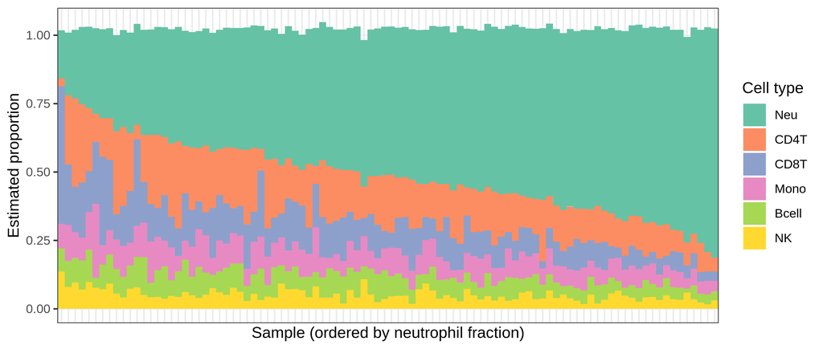

Figure 4.1: Estimated cell-type proportions per sample (stacked). The neutrophil fraction has the largest variance (17-84%) across individuals. Unaccounted for this variation could confound association testing results.

```r
# reshape() wants a data.frame with an id column, so the matrix goes wide-to-long
# by hand here: one row per sample x cell type, which is what geom_col stacks.
pl <- as.data.frame(props); pl$sample_id <- rownames(pl)
plm <- reshape(pl, varying = colnames(props), v.names = "prop",
               timevar = "cell", times = colnames(props),
               direction = "long")
# Stacking order follows the factor order, so set it explicitly. ggplot2 draws
# the first level at the top of each bar, so neutrophils form the top band and
# NK cells the bottom one.
plm$cell <- factor(plm$cell, levels = c("Neu","CD4T","CD8T","Mono","Bcell","NK"))
# Order the bars by neutrophil fraction so the gradient across samples is
# visible instead of being scattered by array order.
ord <- order(props[,"Neu"]); plm$sample_id <- factor(plm$sample_id,
                                                     levels = rownames(props)[ord])
ggplot(plm, aes(sample_id, prop, fill = cell)) +
  geom_col(width = 1) +
  scale_fill_brewer(palette = "Set2") +
  labs(x = "Sample (ordered by neutrophil fraction)", y = "Estimated proportion",
       fill = "Cell type") +
  theme_bw(base_size = 11) +
  theme(axis.text.x = element_blank(), axis.ticks.x = element_blank())
```

## 4.4 Validation against the deposited answer key

The Grady Trauma Project deposited its own cell-type proportion estimates with the GEO record. That gives us the opportunity to check our deconvolution.

```r
# The deposited proportions are part of the GEO record's *phenotype*, not of the
# IDATs, so they come out of the series matrix rather than out of `rg`. GEOquery
# parses each "label: value" characteristic into its own column named
# "<label>:ch1", which is where the six proportions are found.
dep_file <- "data/04_deposited_cellcounts.tsv"

if (file.exists(dep_file)) {
  dep <- fread(dep_file, data.table = FALSE)
} else {
  # 60 seconds is not enough to pull 30 MB from GEO on a slow link.
  options(timeout = max(1200, getOption("timeout")))

  # getGPL = FALSE skips the platform manifest, which we do not need here.
  gse <- getGEO("GSE132203", GSEMatrix = TRUE, getGPL = FALSE)[[1]]
  pd  <- Biobase::pData(gse)

  # Our cell-type names on the left, GEO's column names on the right.
  dep_cols <- c(CD8T = "cd8t:ch1", CD4T = "cd4t:ch1", NK = "nk:ch1",
                Bcell = "bcell:ch1", Mono = "mono:ch1", Neu = "neu:ch1")

  # Everything out of a series matrix is text, including the numbers.
  dep <- as.data.frame(lapply(dep_cols,
                              function(k) as.numeric(as.character(pd[[k]]))))
  dep$sample_id <- as.character(pd$geo_accession)

  # The series carries 795 samples. Joining onto our 96 sample IDs keeps only
  # the samples on our plate subset
  dep <- left_join(data.frame(sample_id = rownames(props)), dep, by = "sample_id")
}
```

```r
cells <- c("CD8T","CD4T","NK","Bcell","Mono","Neu")

# One row per sample with our estimated cell proportions versus and the deposited
# cell proportions side by side. A suffix is added to differentiate which dataset
# the cell proportion estimate came from.
m <- as.data.frame(props) %>%
  rownames_to_column("sample_id") %>%
  inner_join(dep, by = "sample_id", suffix = c(".est", ".dep"))

# Summaries per cell type: correlation says whether the
# between-sample variation agrees (the part that matters for confounding
# adjustment), mean absolute error says how far apart the absolute values are,
# and the two means expose a systematic offset the correlation would hide.
res <- data.frame(cell = cells, r = NA_real_, mae = NA_real_,
                  mean_est = NA_real_, mean_dep = NA_real_)
for (i in seq_along(cells)) {
  e <- m[[paste0(cells[i], ".est")]]
  d <- m[[paste0(cells[i], ".dep")]]
  res$r[i]        <- cor(e, d, use = "complete.obs")
  res$mae[i]      <- mean(abs(e - d), na.rm = TRUE)
  res$mean_est[i] <- mean(e, na.rm = TRUE)
  res$mean_dep[i] <- mean(d, na.rm = TRUE)
}

# The per-sample comparison and the per-cell-type summary
val <- list(merged = m, validation = res)
```

```r
disp <- data.frame(
  `cell type`        = res$cell,
  `Pearson r`        = sprintf("%.3f", res$r),
  `mean abs. error`  = sprintf("%.4f", res$mae),
  `our mean`         = sprintf("%.1f%%", 100*res$mean_est),
  `deposited mean`   = sprintf("%.1f%%", 100*res$mean_dep),
  check.names = FALSE)
knitr::kable(disp, caption = "Our estimates vs the study's deposited proportions, per cell type (n = 96).")
```

Our estimates vs the study’s deposited proportions, per cell type (n = 96).

| cell type | Pearson r | mean abs. error | our mean | deposited mean |
| --- | --- | --- | --- | --- |
| CD8T | 0.993 | 0.0066 | 11.7% | 11.8% |
| CD4T | 0.993 | 0.0100 | 16.4% | 15.5% |
| NK | 0.953 | 0.0095 | 5.2% | 4.2% |
| Bcell | 0.963 | 0.0140 | 7.0% | 5.6% |
| Mono | 0.989 | 0.0044 | 8.5% | 8.3% |
| Neu | 0.997 | 0.0112 | 53.6% | 54.5% |

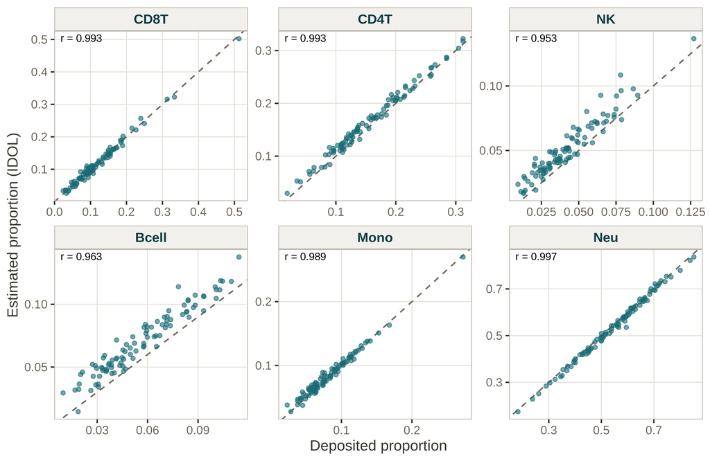

Figure 4.2: Estimated (y) vs deposited (x) proportions for each cell type. Every estimated cell type correlates > 0.95 with the deposited cell types with mean absolute error under 1.5%. Our newly estimated cell type proportions successfully reproduce what was reported by the original study.

```r
# Six panels, one per cell type, so stack the pairs into a long table.
long <- bind_rows(lapply(cells, function(k)
  data.frame(cell = k, est = m[[paste0(k, ".est")]], dep = m[[paste0(k, ".dep")]]))) %>%
  mutate(cell = factor(cell, levels = cells))

# The correlation from the table above, printed in each panel's corner
labs_r <- data.frame(cell = factor(res$cell, levels = cells),
                     lab  = sprintf("r = %.3f", res$r))

p_val <- ggplot(long, aes(dep, est)) +
  # y = x first, so the points sit on top of it.
  geom_abline(slope = 1, intercept = 0, linetype = "dashed", color = "#6E675B") +  # gray
  geom_point(alpha = .6, size = 1.3, color = "#1A6B75") +                          # teal
  facet_wrap(~cell, scales = "free") +
  geom_text(data = labs_r, aes(x = -Inf, y = Inf, label = lab),
            hjust = -0.15, vjust = 1.5, size = 3, inherit.aes = FALSE) +
  labs(x = "Deposited proportion", y = "Estimated proportion (IDOL)")
p_val
```

Correlations range from **0.953** (NK, the rarest and hardest-to-estimate type) to **0.997** (neutrophils), and the mean absolute error never exceeds **1.4 percentage points**. Small systematic offsets (e.g. our B-cell estimates run slightly high) are expected when the reference library or normalization differs from the original authors’, and they matter far less than the near-perfect *ranking* — because in the EWAS model it is the between-sample variation, not the absolute level, that does the confounding adjustment.

**TipPractical note**

Many studies do not provide cell proportions. In a real analysis you trust the method and **sanity-check the output**: neutrophils should dominate whole blood (~50–70%), proportions should sum to ~1, and the distribution should look biologically plausible.

## 4.5 Saving what we just computed

We carry the estimated proportions forward as EWAS covariates:

```r
# 1. The proportions themselves: a 96 x 6 matrix with GSM ids as rownames. This
#    is the file the later chapters read when they need cell-type covariates.
saveRDS(props, "data/04_cellcounts.rds")

# 2. The whole estimateCellCounts2() return, as deposited in the Zenodo record.
#    Keeping the full object means the file on record is the object the code
#    above produced, with nothing dropped or coerced.
saveRDS(cc, "data/04_cc_full.rds")

# 3. The validation: the per-sample comparison (`merged`) and the per-cell-type
#    summary (`validation`) that the table, the figure and the paragraph above
#    are all drawn from.
saveRDS(val, "data/04_validation.rds")

# 4. The deposited proportions as a tsv
write.table(dep, "data/04_deposited_cellcounts.tsv",
            sep = "\t", row.names = FALSE, quote = FALSE)

# 5. The validation figure at the size the rendered page uses.
ggsave("data/04_validation_scatter.png", p_val, width = 8, height = 5.2, dpi = 130)
```

Proportions are estimated for all **96** QC-passing arrays. Deconvolution does not use the exposure, so there is no reason to restrict it to the modeled subset here — the nine samples with no recorded PTSD status (chapter 1) drop out later, when the exposure enters the model, as does the one sample with no genetic ancestry PCs (Genetic ancestry PCs), leaving n = 86 for the EWAS.

## 4.6 When you don’t have IDATs: deconvolution from a processed matrix

Reference-based deconvolution normally wants the raw `RGChannelSet`, so a β-matrix-only deposit is the harder case. Two routes:

1. **`projectCellType` on a β-matrix.** The Houseman projection itself only needs methylation *values* at the reference CpGs, not intensities. Pull the reference β-values and its cell-type means, subset your matrix to the shared reference CpGs, and run the constrained projection directly:

   ```
   Generic example, do not run
   ```

   ```r
   # Schematic only. `beta_mat` is a CpG x sample matrix -- in the deposit-only
   # case, whatever the submitter posted; locally, getBeta() on the chapter 3
   # object gives one. The result is deliberately NOT called `props`: that name
   # refers to this chapter's IDOL estimates, and overwriting it would cause
   # serious problems downstream.
   library(FlowSorted.Blood.EPIC)
   library(genefilter)
   ref <- ...   # matrix: IDOL CpGs x 6 cell types, from the package
   shared       <- intersect(rownames(beta_mat), rownames(ref))
   props_manual <- minfi:::projectCellType(beta_mat[shared, ], ref[shared, ])
   ```

   The estimates are slightly noisier than the joint-normalization route because the sample and reference weren’t normalized together, but for a well-processed matrix they are close.
2. **`EpiDISH` (reference-based, matrix-native).** The `EpiDISH` package (Teschendorff et al. 2017) is designed to take a β-matrix plus a reference centroid matrix and return proportions via robust partial correlation (RPC), CIBERSORT, or constrained projection. It ships blood reference centroids and is the most convenient option when you only have processed data:

   ```
   Generic example, do not run
   ```

   ```r
   # Schematic only. `beta_mat` stands for your own CpG x sample beta matrix. The
   # result is deliberately not called `props` because that column name already refers
   # to the IDOL estimates.
   library(EpiDISH)
   data(centDHSbloodDMC.m)                     # blood reference centroids
   out <- epidish(beta_mat, ref.m = centDHSbloodDMC.m, method = "RPC")
   props_epidish <- out$estF
   ```

**NoteReference-free alternatives**

When no suitable reference exists (unusual tissues, or you worry the reference doesn’t match your population), **reference-free** methods estimate latent composition-like components directly from the data: RefFreeEWAS (Houseman et al. 2016), SVA (Leek et al. 2012), and RUV. This tutorial does not use RefFreeEWAS; SVA is used in batch effects to capture unmeasured variation, and RUV is mentioned there. The trade-off is that the recovered components are not labeled cell types, only surrogate variables to adjust for.

**Next:** Genetic ancestry PCs — what the three ancestry covariates used from chapter 6 onwards are and why we use them in statistical modeling.

## References

Houseman, Eugene Andres, William P Accomando, Devin C Koestler, et al. 2012. “DNA Methylation Arrays as Surrogate Measures of Cell Mixture Distribution.” *BMC Bioinformatics* 13: 86. https://doi.org/10.1186/1471-2105-13-86.

Houseman, Eugene Andres, Molly L Kile, David C Christiani, Tan A Ince, Karl T Kelsey, and Carmen J Marsit. 2016. “Reference-Free Deconvolution of DNA Methylation Data and Mediation by Cell Composition Effects.” *BMC Bioinformatics* 17: 259. https://doi.org/10.1186/s12859-016-1140-4.

Jaffe, Andrew E, and Rafael A Irizarry. 2014. “Accounting for Cellular Heterogeneity Is Critical in Epigenome-Wide Association Studies.” *Genome Biology* 15 (2): R31. https://doi.org/10.1186/gb-2014-15-2-r31.

Leek, Jeffrey T, W Evan Johnson, Hilary S Parker, Andrew E Jaffe, and John D Storey. 2012. “The Sva Package for Removing Batch Effects and Other Unwanted Variation in High-Throughput Experiments.” *Bioinformatics* 28 (6): 882–83. https://doi.org/10.1093/bioinformatics/bts034.

Salas, Lucas A, Devin C Koestler, Rondi A Butler, et al. 2018. “An Optimized Library for Reference-Based Deconvolution of Whole-Blood Biospecimens Assayed Using the Illumina HumanMethylationEPIC BeadArray.” *Genome Biology* 19 (1): 64. https://doi.org/10.1186/s13059-018-1448-7.

Teschendorff, Andrew E, Charles E Breeze, Shijie C Zheng, and Stephan Beck. 2017. “A Comparison of Reference-Based Algorithms for Correcting Cell-Type Heterogeneity in Epigenome-Wide Association Studies.” *BMC Bioinformatics* 18 (1): 105. https://doi.org/10.1186/s12859-017-1511-5.